# Analysis Challenge Assignment 3

**Author**: Nicolas Dussaillant

**Date**: 11/7/2021

HUDK4050 Core Methods in Educational Data Science

## 1. Problem

The requirement for this anaylisis is to generate identifiable clusters between colleges to improve the access to relevant information needed for non-profits in order to enhance the achievements of underprivileged students.

To address this problem the College Scoreboard dataset will be used in order to extract some of its data, process it, and propose a method and results from a clustering procedure. For puporses of replicability, the file will be assumed to be accesible by the person trying to replicate this code.

## 2. Approach to the problem

First we will prepare the dataset and filter all the data that won't be considered. For this we will do the following:

1. Delete schools out of the US mainland (**STABBR**).
2. Select only schools that have at least Bachelor's degree (**HIGHDEG**).
3. Consider only currently operating institutions (**CURROPER**).
4. Remove all schools with missing data in the columns listed in this approach.

To approach this problem, we will do a clustering considering data relevant to school admission, retention, program completion, financial aids, and costs. In this way, we will identify groups that can be categorized within similarities in those criterias. These groups will allow potential students to find schools that are easy to get in and/or probable to complete and/or possible to fund.

The data used to identify and cluster the institutions will be:

1. Cost of attendance (**NPT4_PUB** and **NPT4_PRIV**) (We will create one field [cost] regardless the control of the institution).
2. Percent of Undergraduates Receiving Federal Loans (**PCTFLOAN**)
3. Completion rate for first-time, full-time students at four-year institutions (150% of expected time to completion/6 years) (**C150_4**)
4. First-time, full-time student retention rate at four-year institutions (**RET_FT4**)
5. Admission rate (**ADM_RATE**)

For this approach we will not consider data describing the students by their family incomes, being first-generation, ethnicity or race, gender, or other similar personal data, due to the purpose is to identify schools regardless these factors. This is because otherwise we will be suggesting institutions according to the family or the personal information of the student, and creating a more segregated post-secondary system.

## 3. Procedure

### 3.1 Environment preparation

```python
import numpy as np
import pandas as pd
import matplotlib.pyplot as plt
import seaborn as sns
from sklearn.cluster import KMeans
from sklearn.preprocessing import StandardScaler
from sklearn.decomposition import PCA
```

### 3.2 Data preparation

Here we will prepare the data to work with.

First we import the data and remove what we won't be considering or using.

```python
# Function to parse data from some of the columns
convint = lambda x : int(float(x)) if x != '' else 0
```

```python
# Read the csv
college_data = pd.read_csv('CollegeScorecard.csv',
                            sep = ',',
                            usecols = ['INSTNM',
                                       'UNITID',
                                       'STABBR',
                                       'HIGHDEG',
                                       'CURROPER',
                                       'LATITUDE',
                                       'LONGITUDE',
                                       'ADM_RATE',
                                       'NPT4_PUB',
                                       'NPT4_PRIV',
                                       'PCTFLOAN',
                                       'C150_4',
                                       'RET_FT4',
                                      ],
                            dtype = {
                                    'INSTNM' : str,
                                    'UNITID' : str,
                                    'STABBR' : str,
                                    'HIGHDEG': int,
                                    'CURROPER': int,
                                    'LATITUDE': float,
                                    'LONGITUDE': float,
                                    'ADM_RATE': float,
                                    'PCTFLOAN': float,
                                    'C150_4': float,
                                    'RET_FT4': float,
                                },
                            converters = {
                                    'NPT4_PUB' : convint,
                                    'NPT4_PRIV': convint
                                }
                            )

# Remove Schools from
# Puerto Rico, Alaska, Marshall Islands, Palau, Micronesia, Samoa, Guam, Mariana, Virgin Islands and Hawaii
mask = (college_data['STABBR'] == 'PR') | (college_data['STABBR'] == 'AK') | (college_data['STABBR'] == 'HI')
mask = mask | (college_data['STABBR'] == 'FM') | (college_data['STABBR'] == 'PW') | (college_data['STABBR'] == 'MH')
mask = mask | (college_data['STABBR'] == 'AS') | (college_data['STABBR'] == 'GU') | (college_data['STABBR'] == 'MP')
mask = mask | (college_data['STABBR'] == 'VI')

# Only schools that have at least bachelor's degre:
mask = mask | (college_data['HIGHDEG'] < 3)

# Only currently operating institutions:
mask = mask | (college_data['CURROPER'] == 0)

# Filtering rows with missing data (missing data is computed as NaN)
for c in college_data.columns:
    mask = mask | pd.isna(college_data[c])

college_data.drop(college_data[mask].index, inplace=True)

display(college_data)
```

|  | UNITID | INSTNM | STABBR | HIGHDEG | LATITUDE | LONGITUDE | ADM_RATE | CURROPER | NPT4_PUB | NPT4_PRIV | C150_4 | RET_FT4 | PCTFLOAN |
| --- | --- | --- | --- | --- | --- | --- | --- | --- | --- | --- | --- | --- | --- |
| 0 | 100654 | Alabama A & M University | AL | 4 | 34.7834 | -86.5685 | 0.8989 | 1 | 13415 | 0 | 0.2914 | 0.6314 | 0.8204 |
| 1 | 100663 | University of Alabama at Birmingham | AL | 4 | 33.5022 | -86.8092 | 0.8673 | 1 | 14805 | 0 | 0.5377 | 0.8016 | 0.5397 |
| 3 | 100706 | University of Alabama in Huntsville | AL | 4 | 34.7228 | -86.6384 | 0.8062 | 1 | 17520 | 0 | 0.4835 | 0.8098 | 0.4728 |
| 4 | 100724 | Alabama State University | AL | 4 | 32.3643 | -86.2957 | 0.5125 | 1 | 11936 | 0 | 0.2517 | 0.6219 | 0.8735 |
| 5 | 100751 | The University of Alabama | AL | 4 | 33.2144 | -87.5458 | 0.5655 | 1 | 20916 | 0 | 0.6665 | 0.8700 | 0.4148 |
| ... | ... | ... | ... | ... | ... | ... | ... | ... | ... | ... | ... | ... | ... |
| 6373 | 455257 | Yeshiva of Machzikai Hadas | NY | 3 | 40.6383 | -73.9878 | 1.0000 | 1 | 0 | 14976 | 0.5172 | 0.8451 | 0.0000 |
| 6411 | 455770 | Providence Christian College | CA | 3 | 34.1718 | -118.1187 | 0.5328 | 1 | 0 | 17364 | 0.5385 | 0.6364 | 0.5625 |
| 6590 | 458113 | Bethel College | VA | 3 | 37.0401 | -76.4087 | 1.0000 | 1 | 0 | 10863 | 0.0000 | 0.5000 | 0.7612 |
| 6917 | 462354 | John Paul the Great Catholic University | CA | 4 | 32.8996 | -117.1077 | 0.8815 | 1 | 0 | 29341 | 0.5152 | 0.7436 | 0.5362 |
| 6928 | 466921 | Chamberlain College of Nursing-Missouri | MO | 3 | 38.7028 | -90.4360 | 0.6000 | 1 | 0 | 22547 | 0.3333 | 0.7778 | 0.8944 |

1599 rows × 13 columns

Then, we format the columns that we will use throughout the process:

```python
# Create column cost:
college_data['Cost'] = college_data['NPT4_PUB'] + college_data['NPT4_PRIV']

# Rename columns
data = college_data.rename(columns =
                          {
                              'INSTNM' : 'Name',
                              'LATITUDE' : 'Lat',
                              'LONGITUDE': 'Long',
                              'ADM_RATE' : 'Adm_rate',
                              'C150_4' : 'Completion_rate',
                              'RET_FT4': 'Ret_rate',
                              'PCTFLOAN': 'Perc_loans'
                          })

# Drop columns no longer needed
data.drop(columns = ['STABBR', 'HIGHDEG', 'CURROPER', 'NPT4_PUB', 'NPT4_PRIV'], inplace=True)
display(data)
```

|  | UNITID | Name | Lat | Long | Adm_rate | Completion_rate | Ret_rate | Perc_loans | Cost |
| --- | --- | --- | --- | --- | --- | --- | --- | --- | --- |
| 0 | 100654 | Alabama A & M University | 34.7834 | -86.5685 | 0.8989 | 0.2914 | 0.6314 | 0.8204 | 13415 |
| 1 | 100663 | University of Alabama at Birmingham | 33.5022 | -86.8092 | 0.8673 | 0.5377 | 0.8016 | 0.5397 | 14805 |
| 3 | 100706 | University of Alabama in Huntsville | 34.7228 | -86.6384 | 0.8062 | 0.4835 | 0.8098 | 0.4728 | 17520 |
| 4 | 100724 | Alabama State University | 32.3643 | -86.2957 | 0.5125 | 0.2517 | 0.6219 | 0.8735 | 11936 |
| 5 | 100751 | The University of Alabama | 33.2144 | -87.5458 | 0.5655 | 0.6665 | 0.8700 | 0.4148 | 20916 |
| ... | ... | ... | ... | ... | ... | ... | ... | ... | ... |
| 6373 | 455257 | Yeshiva of Machzikai Hadas | 40.6383 | -73.9878 | 1.0000 | 0.5172 | 0.8451 | 0.0000 | 14976 |
| 6411 | 455770 | Providence Christian College | 34.1718 | -118.1187 | 0.5328 | 0.5385 | 0.6364 | 0.5625 | 17364 |
| 6590 | 458113 | Bethel College | 37.0401 | -76.4087 | 1.0000 | 0.0000 | 0.5000 | 0.7612 | 10863 |
| 6917 | 462354 | John Paul the Great Catholic University | 32.8996 | -117.1077 | 0.8815 | 0.5152 | 0.7436 | 0.5362 | 29341 |
| 6928 | 466921 | Chamberlain College of Nursing-Missouri | 38.7028 | -90.4360 | 0.6000 | 0.3333 | 0.7778 | 0.8944 | 22547 |

1599 rows × 9 columns

### 3.3 Clustering

#### 3.3.1 Analyze data

Here we will look if there are relationships between variables that could lead to a PCA between the continuous variables, but we will start standardizing the scale of all the continuous variables:

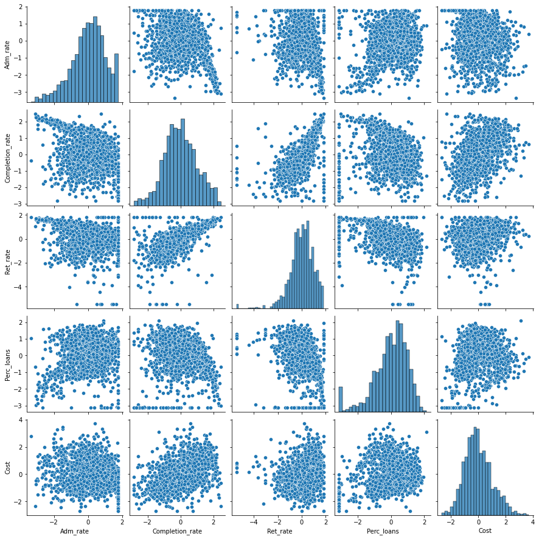

```python
cont_data = data[['Adm_rate', 'Completion_rate', 'Ret_rate', 'Perc_loans', 'Cost']]
scale = StandardScaler()
scale.fit(cont_data)
st_cont_data = pd.DataFrame(scale.transform(cont_data), columns = ['Adm_rate', 'Completion_rate', 'Ret_rate', 'Perc_loans', 'Cost'])

sns.pairplot(st_cont_data)#, hue = "certified")
```

Between completion rate and retention rate apparently there is a correlation. Let's find out for all the variables:

```python
cont_data_pca = PCA()
cont_data_pca.fit(st_cont_data)

print("The principal components are:")
print(cont_data_pca.components_)
print("The explained variances are:")
print(cont_data_pca.explained_variance_)
```

```
The principal components are:
[[ 0.3509214  -0.61460378 -0.57338834  0.24121058 -0.33490242]
 [ 0.04365199 -0.08170739  0.18417188 -0.73335893 -0.64783007]
 [-0.9268368  -0.13650193 -0.2458494   0.09967038 -0.22795756]
 [-0.06459356 -0.17125868 -0.46750099 -0.62770483  0.59491816]
 [ 0.10839688  0.75340811 -0.59858786 -0.00738857 -0.24952817]]
The explained variances are:
[2.11902179 1.25344281 0.85199291 0.49423595 0.28443545]
```

There are not very big differences between explained variances. Let's try just with Retention and Completion

```python
comp_ret_pca = PCA()
comp_ret_pca.fit(st_cont_data[['Completion_rate', 'Ret_rate']])

print("The principal components are:")
print(comp_ret_pca.components_)
print("The explained variances are:")
print(comp_ret_pca.explained_variance_)
```

```
The principal components are:
[[-0.70710678 -0.70710678]
 [ 0.70710678 -0.70710678]]
The explained variances are:
[1.66840837 0.3328432 ]
```

There is also not a very big difference. We will use all the variables for clustering, without using principal components.

#### 3.3.2 Clustering

For the clustering we will use K-means repeatedly and find the "elbow" in the graph to determine a good number of clusters (K).

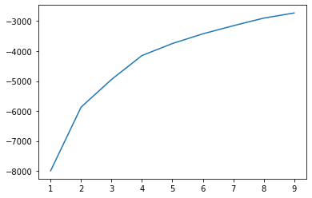

```python
k = range(1, 10)
kms = [KMeans(n_clusters=i) for i in k]
scores = [kms[i].fit(st_cont_data).score(st_cont_data) for i in range(len(kms))]
plt.plot(k, scores)
```

We decide to use K = 4, because is where the slope starts to have a very similar slope (almost constant)

```python
clusters = kms[4 - 1].predict(st_cont_data)

data['Cluster'] = clusters
```

Create the groups:

```python
cluster0 = data[data['Cluster'] == 0]
cluster1 = data[data['Cluster'] == 1]
cluster2 = data[data['Cluster'] == 2]
cluster3 = data[data['Cluster'] == 3]
```

#### 3.3.3 Analyze each cluster

Now we use descriptive statistics to analyze the composition of each cluster:

```python
display(cluster0.describe())
display(cluster1.describe())
display(cluster2.describe())
display(cluster3.describe())
```

|  | Lat | Long | Adm_rate | Completion_rate | Ret_rate | Perc_loans | Cost | Cluster |
| --- | --- | --- | --- | --- | --- | --- | --- | --- |
| count | 475.000000 | 475.000000 | 475.000000 | 475.000000 | 475.000000 | 475.000000 | 475.000000 | 475.0 |
| mean | 37.673402 | -86.815141 | 0.619684 | 0.392446 | 0.623607 | 0.733271 | 17621.345263 | 0.0 |
| std | 4.788439 | 11.068683 | 0.174193 | 0.116949 | 0.132122 | 0.101831 | 4782.370768 | 0.0 |
| min | 25.795200 | -123.238800 | 0.133600 | 0.000000 | 0.000000 | 0.339400 | 0.000000 | 0.0 |
| 25% | 34.080450 | -92.426450 | 0.512350 | 0.325750 | 0.577700 | 0.663450 | 14473.000000 | 0.0 |
| 50% | 38.332600 | -84.362600 | 0.607600 | 0.398500 | 0.649700 | 0.737400 | 17473.000000 | 0.0 |
| 75% | 41.318500 | -79.949300 | 0.730650 | 0.467300 | 0.704150 | 0.810500 | 20141.500000 | 0.0 |
| max | 47.710900 | -68.789900 | 1.000000 | 0.891900 | 1.000000 | 0.948900 | 37460.000000 | 0.0 |

|  | Lat | Long | Adm_rate | Completion_rate | Ret_rate | Perc_loans | Cost | Cluster |
| --- | --- | --- | --- | --- | --- | --- | --- | --- |
| count | 602.000000 | 602.000000 | 602.000000 | 602.000000 | 602.000000 | 602.000000 | 602.000000 | 602.0 |
| mean | 39.903467 | -86.244537 | 0.711354 | 0.615382 | 0.801714 | 0.656241 | 23070.149502 | 1.0 |
| std | 3.980573 | 14.168889 | 0.129590 | 0.101478 | 0.066751 | 0.108624 | 5828.597466 | 0.0 |
| min | 26.078900 | -123.274200 | 0.260300 | 0.100000 | 0.560000 | 0.300000 | 11395.000000 | 1.0 |
| 25% | 38.313000 | -91.481650 | 0.631650 | 0.558200 | 0.758425 | 0.581025 | 18728.750000 | 1.0 |
| 50% | 40.737000 | -82.177700 | 0.717600 | 0.618100 | 0.804850 | 0.667000 | 22273.000000 | 1.0 |
| 75% | 42.336825 | -75.881025 | 0.796775 | 0.684250 | 0.848950 | 0.727875 | 26197.750000 | 1.0 |
| max | 48.737200 | -68.228800 | 1.000000 | 0.909100 | 1.000000 | 1.000000 | 45774.000000 | 1.0 |

|  | Lat | Long | Adm_rate | Completion_rate | Ret_rate | Perc_loans | Cost | Cluster |
| --- | --- | --- | --- | --- | --- | --- | --- | --- |
| count | 193.000000 | 193.000000 | 193.000000 | 193.000000 | 193.000000 | 193.000000 | 193.000000 | 193.0 |
| mean | 39.137134 | -86.636038 | 0.374889 | 0.832134 | 0.924033 | 0.384150 | 24182.538860 | 2.0 |
| std | 4.070168 | 16.936849 | 0.172241 | 0.097507 | 0.045089 | 0.134823 | 7910.982936 | 0.0 |
| min | 25.720400 | -123.030700 | 0.000000 | 0.466700 | 0.714300 | 0.000000 | 2584.000000 | 2.0 |
| 25% | 36.001600 | -93.183600 | 0.254900 | 0.790200 | 0.902200 | 0.318300 | 17802.000000 | 2.0 |
| 50% | 40.428200 | -79.051000 | 0.375000 | 0.842600 | 0.930300 | 0.396400 | 24936.000000 | 2.0 |
| 75% | 42.275100 | -73.962400 | 0.494200 | 0.907300 | 0.957400 | 0.474700 | 29597.000000 | 2.0 |
| max | 47.668100 | -69.663400 | 0.821600 | 1.000000 | 1.000000 | 0.797000 | 43952.000000 | 2.0 |

|  | Lat | Long | Adm_rate | Completion_rate | Ret_rate | Perc_loans | Cost | Cluster |
| --- | --- | --- | --- | --- | --- | --- | --- | --- |
| count | 329.000000 | 329.000000 | 329.000000 | 329.000000 | 329.000000 | 329.000000 | 329.000000 | 329.0 |
| mean | 38.391785 | -91.306658 | 0.759745 | 0.421270 | 0.734497 | 0.411592 | 11695.823708 | 3.0 |
| std | 4.763186 | 14.726998 | 0.173213 | 0.149914 | 0.104150 | 0.189179 | 3976.143499 | 0.0 |
| min | 25.742600 | -124.081400 | 0.232800 | 0.000000 | 0.218200 | 0.000000 | 0.000000 | 3.0 |
| 25% | 35.127400 | -98.172100 | 0.637900 | 0.346600 | 0.672100 | 0.365300 | 9169.000000 | 3.0 |
| 50% | 38.957400 | -88.742400 | 0.776600 | 0.436900 | 0.737000 | 0.456000 | 11894.000000 | 3.0 |
| 75% | 41.331900 | -80.377600 | 0.891100 | 0.511700 | 0.798500 | 0.547200 | 14235.000000 | 3.0 |
| max | 48.541100 | -67.456500 | 1.000000 | 0.878800 | 1.000000 | 0.743900 | 28686.000000 | 3.0 |

Now we analyze the different separation between the variables

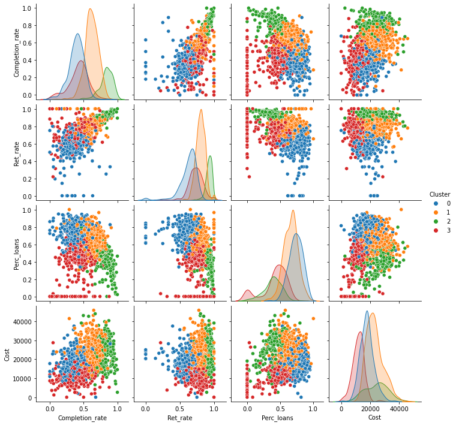

```python
sns.pairplot(data[['Completion_rate', 'Ret_rate', 'Perc_loans', 'Cost', 'Cluster']], hue = 'Cluster', palette = 'tab10')
```

And let's see the geographical distribution:

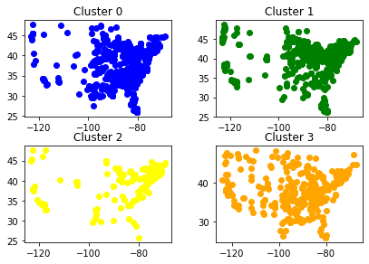

```python
fig, ((ax0, ax1), (ax2, ax3)) = plt.subplots(2, 2)
fig.tight_layout()

ax0.scatter(cluster0['Long'], cluster0['Lat'], c='blue')
ax0.set_title('Cluster 0')

ax1.scatter(cluster1['Long'], cluster1['Lat'], c='green')
ax1.set_title('Cluster 1')

ax2.scatter(cluster2['Long'], cluster2['Lat'], c='yellow')
ax2.set_title('Cluster 2')

ax3.scatter(cluster3['Long'], cluster3['Lat'], c='orange')
ax3.set_title('Cluster 3')

plt.show()
```

In general, more institutions are in the east side of the country. Apparently there is no trend for any cluster to go specifically to certain geographical regions, except for cluster 3 that looks like it has a little bit more institutions in the west compared to the other clusters.

## 4. Results

In this sections I present the results of the analysis made.

### 4.1 Clusters:

The schools for each clusters are the following:

```python
print("Cluster 0")
display(cluster0['UNITID'].to_numpy())
```

```
Cluster 0
```

```
array(['100654', '100724', '100830', '101116', '101365', '101435',
       '101480', '101541', '101587', '101879', '101912', '102261',
       '102270', '102377', '104717', '105172', '105589', '105899',
       '106342', '106412', '106713', '107071', '107877', '112084',
       '112570', '115728', '119775', '120537', '123457', '124487',
       '126182', '127653', '127741', '128744', '129774', '130183',
       '130448', '130934', '130989', '131098', '131876', '132471',
       '132602', '132842', '133085', '133465', '133526', '133650',
       '133809', '133872', '133979', '134945', '136206', '137476',
       '137564', '137953', '138275', '138293', '138309', '138716',
       '138789', '138868', '138947', '139199', '139205', '139311',
       '139366', '139579', '139630', '139719', '139764', '140164',
       '140234', '140252', '140340', '140720', '140818', '140872',
       '140960', '140988', '141167', '141185', '141264', '141334',
       '141361', '143288', '144005', '144351', '144971', '145372',
       '146667', '146676', '146825', '147013', '147703', '148131',
       '148335', '148405', '148487', '148627', '149222', '149514',
       '149772', '150172', '150774', '151166', '151290', '151519',
       '151777', '151786', '152336', '153001', '153278', '153366',
       '153621', '153861', '153977', '154004', '154493', '154518',
       '154590', '154721', '154749', '154855', '155025', '155070',
       '155089', '155414', '155496', '155511', '155520', '155627',
       '155812', '155937', '155973', '156189', '156356', '156541',
       '157058', '157076', '157100', '157535', '157757', '157863',
       '158802', '159009', '159568', '160065', '160074', '160621',
       '160630', '160904', '161226', '161563', '161873', '162007',
       '162210', '162283', '162584', '163338', '163453', '164447',
       '164614', '164632', '164641', '164720', '165574', '165802',
       '165820', '165866', '166948', '167251', '167455', '168528',
       '169327', '169798', '170000', '170037', '170842', '170967',
       '171146', '171599', '171881', '172051', '172264', '172440',
       '173124', '173142', '173328', '174154', '174206', '174525',
       '174862', '175014', '175227', '175342', '175421', '175856',
       '176035', '176044', '176053', '176318', '176372', '176406',
       '176628', '176910', '176947', '177144', '177339', '177418',
       '177542', '177968', '178369', '178402', '180258', '180595',
       '180832', '181093', '181330', '181604', '181738', '181853',
       '182661', '182980', '183822', '183910', '185129', '186432',
       '186618', '187444', '188340', '190114', '190248', '190725',
       '190761', '190770', '191205', '191621', '192439', '192785',
```

[output cut: 25 more lines]

```
       '226383', '226471', '226587', '227243', '227331', '227429',
       '227526', '228042', '228325', '228431', '228468', '228501',
       '228529', '228705', '228769', '228981', '229063', '229160',
       '230603', '230825', '230889', '230898', '230913', '230931',
       '231077', '231086', '231095', '231165', '231420', '231554',
       '231837', '232025', '232089', '232557', '232937', '233611',
       '234155', '234164', '237118', '237181', '237215', '237312',
       '237330', '237358', '237367', '237640', '237899', '237950',
       '238193', '238324', '238430', '238980', '239071', '239080',
       '239390', '239512', '240392', '240453', '251312', '261931',
       '367884', '368452', '373827', '377069', '377546', '386472',
       '392840', '407063', '414568', '414823', '414878', '417752',
       '433004', '433536', '439701', '442356', '446233', '446905',
       '448673', '448840', '449898', '450571', '455770', '458113',
       '466921'], dtype=object)
```

```python
print("Cluster 1")
display(cluster1['UNITID'].to_numpy())
```

```
Cluster 1
```

```
array(['100858', '100937', '101693', '102049', '102234', '104586',
       '107044', '107080', '107141', '107512', '109651', '109785',
       '110097', '110185', '110361', '110370', '110671', '110714',
       '111188', '112075', '112394', '113698', '114354', '114390',
       '114813', '117140', '117168', '117627', '117751', '118693',
       '118888', '119173', '119270', '120184', '120403', '120865',
       '120883', '121309', '121691', '122454', '122612', '122728',
       '123554', '123651', '123952', '124292', '125727', '125763',
       '125897', '126614', '126669', '126818', '127060', '127918',
       '128498', '128771', '129215', '129242', '129525', '129941',
       '130226', '130253', '130314', '130943', '131283', '131520',
       '132657', '133492', '133553', '133711', '133881', '134079',
       '135081', '136215', '136330', '136774', '136950', '137032',
       '137546', '137847', '138600', '139144', '139393', '139861',
       '139931', '139940', '140447', '140553', '140696', '140951',
       '141060', '142090', '142294', '142461', '142887', '143048',
       '143084', '143118', '143358', '144281', '144740', '144892',
       '144962', '145619', '145646', '145691', '145725', '145813',
       '146339', '146393', '146427', '146481', '146612', '146719',
       '147244', '147341', '147536', '147660', '147679', '147828',
       '148496', '148584', '148849', '149505', '149639', '150066',
       '150136', '150145', '150163', '150455', '150534', '150604',
       '150668', '150677', '150756', '150941', '151263', '151351',
       '151458', '151801', '152318', '152363', '152381', '152390',
       '152530', '152567', '152600', '153108', '153126', '153144',
       '153162', '153250', '153269', '153320', '153375', '153603',
       '153658', '153825', '153834', '154013', '154095', '154101',
       '154235', '154350', '154527', '154688', '154712', '155900',
       '156213', '156286', '156408', '156745', '157377', '157818',
       '158477', '159656', '160959', '161253', '161299', '161457',
       '161509', '161518', '161572', '162061', '162654', '162760',
       '163268', '163295', '163462', '163578', '163851', '163912',
       '163976', '164076', '164173', '164216', '164270', '164492',
       '164562', '165024', '165334', '165529', '165671', '165699',
       '165936', '166018', '166391', '166452', '166513', '166629',
       '166656', '166674', '166692', '166850', '166984', '167260',
       '167288', '167394', '167598', '167783', '167792', '167899',
       '167987', '167996', '168005', '168227', '168254', '168263',
       '168281', '168290', '168546', '168591', '168740', '168786',
       '169080', '169248', '169442', '169479', '169716', '169983',
```

[output cut: 46 more lines]

```
       '219709', '219976', '220215', '220473', '221014', '221661',
       '221971', '222178', '222983', '224323', '227845', '228149',
       '228787', '230807', '230816', '230834', '230852', '230940',
       '230995', '231059', '231174', '231581', '231651', '231712',
       '232043', '232186', '232256', '232308', '232566', '232609',
       '232681', '232706', '233277', '233295', '233301', '233426',
       '233541', '233718', '234030', '234173', '235024', '235769',
       '236133', '236230', '236328', '236452', '236577', '236595',
       '236896', '236939', '237011', '237066', '237969', '238078',
       '238333', '238458', '238476', '238616', '238661', '238892',
       '239017', '239309', '239318', '239628', '239716', '240107',
       '240268', '240329', '240338', '240480', '245652', '366580',
       '367194', '384254', '385619', '409069', '439136', '439288',
       '443410', '445692', '445708', '446048', '449764', '450243',
       '454184', '462354'], dtype=object)
```

```python
print("Cluster 2")
display(cluster2['UNITID'].to_numpy())
```

```
Cluster 2
```

```
array(['100751', '110404', '110413', '110422', '110583', '110635',
       '110644', '110653', '110662', '110680', '110705', '111081',
       '111948', '112260', '115409', '116846', '117946', '120254',
       '121150', '121257', '121345', '122409', '122436', '122506',
       '122931', '123165', '123961', '126678', '126775', '128902',
       '129020', '130590', '130697', '130794', '131159', '131469',
       '131496', '132903', '134097', '134130', '135726', '139658',
       '139755', '139959', '144050', '145637', '147369', '147767',
       '149781', '150400', '152080', '153384', '160755', '160977',
       '161004', '161086', '162928', '163046', '163286', '164465',
       '164580', '164739', '164748', '164924', '164933', '164988',
       '165015', '165662', '166027', '166124', '166683', '166939',
       '167057', '167358', '167835', '168148', '168218', '168342',
       '168421', '170675', '170976', '173258', '173902', '174066',
       '174844', '178697', '179159', '179867', '182670', '186131',
       '186867', '187134', '189088', '189097', '190099', '190150',
       '190372', '190415', '190512', '191126', '191241', '191515',
       '191630', '192040', '192110', '192712', '192819', '193900',
       '194116', '194824', '195030', '195216', '195526', '196079',
       '196088', '196097', '196167', '196176', '196219', '196413',
       '196866', '197133', '197221', '197708', '198385', '198419',
       '198516', '199120', '199193', '199847', '201645', '202523',
       '203535', '204024', '204501', '204796', '206589', '207971',
       '209922', '210401', '211273', '211291', '211440', '211893',
       '212009', '212577', '212674', '212911', '213385', '213543',
       '214175', '214777', '215062', '215293', '216287', '216597',
       '217156', '217402', '217493', '217882', '218070', '218973',
       '221351', '221519', '221999', '223232', '227757', '228246',
       '228343', '228778', '228875', '229267', '230038', '230959',
       '231624', '232265', '232423', '233374', '233921', '234076',
       '234085', '234207', '235316', '236948', '237057', '239105',
       '240444', '243744', '243780', '260813', '399911', '401223',
       '441982'], dtype=object)
```

```python
print("Cluster 3")
display(cluster3['UNITID'].to_numpy())
```

```
Cluster 3
```

```
array(['100663', '100706', '101709', '102094', '102368', '104151',
       '104179', '105330', '106245', '106397', '106458', '106467',
       '106704', '107558', '107983', '108092', '110060', '110486',
       '110495', '110510', '110529', '110538', '110547', '110556',
       '110565', '110574', '110592', '110608', '110617', '110918',
       '115755', '117104', '122597', '122755', '123280', '123572',
       '126076', '126562', '126580', '127185', '127556', '127565',
       '128106', '128391', '130493', '130776', '131450', '132408',
       '133669', '133951', '136172', '137272', '137351', '138354',
       '138558', '139250', '139968', '141097', '141237', '141325',
       '142115', '142285', '142328', '142522', '145497', '145600',
       '147776', '148654', '149231', '149329', '151102', '151111',
       '151306', '151324', '151333', '151342', '151360', '151379',
       '151388', '152099', '152248', '152266', '153241', '155061',
       '155317', '155335', '155399', '155681', '156125', '156295',
       '156365', '156620', '157030', '157085', '157289', '157386',
       '157401', '157447', '157809', '157951', '159382', '159391',
       '159416', '159647', '159717', '159939', '159966', '159993',
       '160038', '160612', '160658', '161165', '161235', '161244',
       '161554', '163532', '165644', '166638', '167729', '168430',
       '169910', '170639', '170806', '171137', '171456', '171571',
       '172033', '172644', '173920', '174020', '174075', '174358',
       '174783', '175078', '175430', '175616', '176017', '176789',
       '176965', '178208', '178244', '178341', '178420', '178615',
       '178624', '178721', '179256', '179326', '179557', '179566',
       '180416', '180461', '180489', '180522', '181215', '181394',
       '182281', '182290', '183071', '184603', '185262', '186186',
       '187648', '187745', '187967', '187985', '188030', '188146',
       '189264', '189273', '189857', '190549', '190558', '190567',
       '190594', '190600', '190637', '190646', '190655', '190664',
       '190691', '192448', '192624', '193052', '193070', '194189',
       '194569', '194657', '194693', '195173', '196042', '196112',
       '196237', '196264', '196431', '196440', '196583', '197601',
       '197610', '197647', '197692', '197735', '197744', '197869',
       '198464', '199111', '199139', '199148', '200059', '200217',
       '200253', '200332', '200572', '200800', '202903', '205124',
       '206084', '206941', '207041', '207263', '207306', '207388',
       '207403', '207500', '207661', '207722', '207847', '207865',
       '209241', '209506', '209807', '210146', '211024', '214670',
       '214731', '214801', '214829', '216311', '217420', '217749',
       '217819', '218441', '219046', '219082', '219259', '219347',
       '219471', '219602', '219790', '219833', '220075', '220312',
       '220613', '220862', '220978', '221759', '221768', '221847',
       '224147', '224554', '225432', '225511', '226152', '226833',
       '227216', '227368', '227863', '227881', '228459', '228723',
       '228796', '228802', '229018', '229027', '229115', '229179',
       '229780', '229814', '230728', '230764', '232672', '232982',
       '233897', '234827', '235097', '235167', '237136', '237385',
       '237525', '237792', '237932', '238032', '239743', '240189',
       '240277', '240365', '240374', '240417', '240426', '240462',
       '240471', '240727', '245777', '247773', '248934', '262129',
       '366711', '377555', '377564', '384421', '405058', '405854',
       '409698', '420325', '426314', '431983', '433660', '434414',
       '436818', '436827', '436836', '441900', '441937', '444413',
       '445188', '449658', '451398', '451404', '455257'], dtype=object)
```

### 4.2 Cluster characteristics

The following table presents the count of each cluster:

[output not shown]

The following table presents the mean of each used variable for each cluster:

[output not shown]

**Cluster 3**: Medium size cluster with the lowest cost and low percentage of federal loans (almost all the institutions with no federal loans were considered in this cluster). Highest admission rate, medium retention rate, and low completion rate.

The variances are not analyzed because they were tried to be minimized during the selection of K and the clustering itself.

## 5. Final comments

At the end, the 4 clusters were identified. The variables chosen were arbitrarly selected and the usage of others could've been evaluated. Probably some variables about the control (public or private) of the institutions, characteristics of their locations, and students' information.

Several other analysis can be made, but they're left for future and further analysis.